# Звіт про заробітні плати у Чехії (ISPV)

## Про джерело та методологію

На відміну від **Work.ua**, який аналізує оголошення про вакансії, дані для Чехії можна отримати з офіційного джерела **ISPV – Informační systém o průměrném výdělku**. ISPV є системою регулярного опитування роботодавців, яку реалізує Міністерство праці та соціальних справ (MPSV) Чехії. Вона збирає детальні відомості про заробітки та відпрацьований/не відпрацьований час, охоплюючи **місячну брутто‑зарплату та погодинний заробіток** у приватному (mzdová sféra) і державному (platová sféra) секторах. На відміну від оголошень на порталах пошуку роботи, ІSPV охоплює фактичні виплати й дозволяє аналізувати зарплати за статтю, віком, освітою, професіями (коди **CZ‑ISCO**) та регіонами (ispv.cz) (data.mpsv.cz).

У цьому звіті використані останні опубліковані результати ISPV для **1 півріччя 2025 року**, а також порівняння з 2024 роком. Деякі показники (особливо детальні таблиці) взято з відкритих наборів даних ISPV та зі статей Kurzy.cz, які перепубліковують таблиці ISPV.

## Загальна ситуація

### Медіанна та середня зарплата

**Медіанна зарплата приватного сектору у попередні періоди:**

| Період | Медіанна брутто‑зарплата | Середня брутто‑зарплата | Джерело |
| --- | --- | --- | --- |
| 2023 (орієнтовно, 3‑й кв. 2023) | **≈37 643 Kč** | **≈44 383 Kč** | звіт ISPV за 3‑й кв. 2023 р. |
| **1 півріччя 2024** | **39 136 Kč** | **48 011 Kč** | ISPV: медіанна зарплата 39 136 Kč, середня 48 011 Kč (ispv.cz) |
| **2024 рік** | **40 709 Kč** | **48 910 Kč** | ISPV: медіанна зарплата 40 709 Kč, середня 48 910 Kč (ispv.cz) |
| **1 півріччя 2025** | **42 101 Kč** | **51 828 Kč** | ISPV: медіанна зарплата 42 101 Kč, середня 51 828 Kč (ispv.cz) |

#### Динаміка середніх і медіанних зарплат

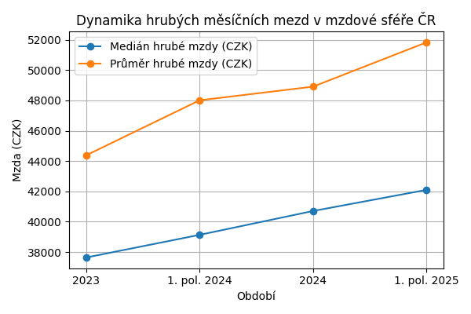

Динаміка заробітних плат в ISPV (2023‑2025)

## Розподіл заробітків

### Децилі та квартилі

За даними ISPV 1 півріччя 2025 року **80 % працівників** мали зарплати між **24 592 Kč** (1‑й дециль) та **85 768 Kč** (9‑й дециль), а співвідношення між дев’ятим і першим децилем дорівнювало **3,5** (ispv.cz). Це відображає рівень нерівності: у найнижчі 10 % працюючі отримували менше 25 тис. Kč, тоді як у найвищі 10 % – понад 85 тис. Kč.

Іншим важливим показником є **1‑й квартиль** (Q1) – 31 814 Kč і **3‑й квартиль** (Q3) – 57 655 Kč (ispv.cz). Отже, половина працівників (між Q1 та Q3) отримує від 32 до 58 тис. Kč на місяць.

### Зарплати за статтю та віком

У 1 півріччі 2025 р. медіанна зарплата чоловіків була 45 587 Kč, а жінок – 37 741 Kč, різниця становить понад 7 тис. Kč (ispv.cz). Найвищі медіанні заробітки відзначаються у віковій групі 30–39 років – 48 517 Kč для чоловіків та 39 997 Kč для жінок (ispv.cz).

### Зарплати за рівнем освіти

Особи з вищою освітою отримують найвищі зарплати: у 1 півріччі 2025 р. медіанна зарплата таких працівників становила **64 699 Kč** (ispv.cz). Працівники з незавершеною чи базовою освітою мали медіанний заробіток ~34 032 Kč (ispv.cz). Люди з дипломом середньої школи та без матури заробляли 36–44 тис. Kč (медіанний рівень) (ispv.cz).

## Найвищі зарплати за професіями (Top‑10)

ISPV надає детальні дані за кожною підгрупою CZ‑ISCO. Згідно з відкритим набором «ISPV – Zaměstnání», що містить медіанну зарплату, середню зарплату та децилі для кожної професії, найвищі медіани у 1 півріччі 2025 р. отримують працівники, пов’язані з авіацією та управлінням**. Таблиця нижче показує 10 підгруп із найвищою медіанною зарплатою (мzdová sféra, 1 півріччя 2025).**

| № | Підгрупа CZ‑ISCO (українською переклад умовний) | Медіанна брутто‑зарплата, Kč | Середня брутто‑зарплата, Kč | Працівників (тис.) |
| --- | --- | --- | --- | --- |
| **1** | **Диспетчери авіаційного руху (Řídící letového provozu)** | **288 609** | 267 135 | 0,4 |
| **2** | Електротехніки навігаційних систем авіаційного руху | 197 297 | 184 864 | 0,1 |
| **3** | Керівники в галузі інформаційних та комунікаційних технологій | 154 054 | 178 427 | 8,5 |
| **4** | Керівники у фінансових та страхових послугах | 139 270 | 181 023 | 3,7 |
| **5** | Керівники у сфері фінансів (крім страхових послуг) | 118 863 | 147 532 | 9,5 |
| **6** | Керівники з управління персоналом | 118 353 | 146 900 | 3,2 |
| **7** | Керівники з науково‑дослідних і розробницьких робіт | 112 845 | 133 470 | 4,6 |
| **8** | Найвищі керівники компаній та установ | 112 034 | 186 003 | 4,9 |
| **9** | Спеціалісти з продажу й закупівлі ІТ‑технологій | 107 532 | 124 629 | 4,6 |
| **10** | Пілоти, навігатори та бортові техніки | 104 817 | 119 379 | 1,4 |

Візуально ці відмінності можна побачити на діаграмі нижче:

[figure not shown]

Топ‑10 професій за медіанною зарплатою

## Регіональні відмінності

| Регіон | 1‑й дециль | 1‑й квартиль | **Медіанна зарплата** | Середня зарплата | 3‑й квартиль | 9‑й дециль | Джерело |
| --- | --- | --- | --- | --- | --- | --- | --- |
| **Прага (Hlavní město Praha)** | 25 091 | 36 168 | **51 522** | 68 239 | 78 609 | 125 426 | ISPV/kurzy.cz (ispv.cz) |
| **Стрідочеський край** | 24 217 | 31 913 | **43 003** | 52 331 | 59 970 | 88 684 | (ispv.cz) |
| **Південночеський (Jihočeský)** | 24 002 | 29 762 | 38 047 | 45 130 | 50 804 | 70 432 | (ispv.cz) |
| **Плзенський** | 25 156 | 32 322 | 41 974 | 48 256 | 54 801 | 74 245 | (ispv.cz) |
| **Карловарський** | 24 225 | 29 564 | **36 995** | 42 252 | 47 915 | 62 808 | (ispv.cz) |
| **Устецький** | 23 802 | 31 124 | 40 987 | 47 111 | 53 556 | 72 309 | (ispv.cz) |
| **Ліберецкий** | 24 106 | 30 695 | 40 091 | 46 041 | 52 796 | 71 209 | (ispv.cz) |
| **Краловоградецький** | 25 119 | 32 333 | 42 076 | 49 266 | 56 535 | 85 581 | (ispv.cz) |
| **Пардубицький** | 24 831 | 30 638 | 38 753 | 43 861 | 49 511 | 64 544 | (ispv.cz) |
| **Височина** | 25 311 | 31 131 | 39 579 | 44 966 | 50 915 | 66 947 | (ispv.cz) |
| **Південноморавський (Jihomoravský)** | 25 369 | 32 766 | 42 632 | 51 260 | 57 141 | 84 313 | (ispv.cz) |
| **Оломоуцький** | 24 100 | 30 152 | 38 918 | 44 081 | 49 754 | 65 889 | (ispv.cz) |
| **Злінський** | 24 025 | 30 365 | 39 212 | 45 604 | 51 836 | 70 355 | (ispv.cz) |
| **Моравськосілезький** | 24 316 | 30 450 | 39 862 | 45 431 | 51 720 | 68 861 | (ispv.cz) |

Графік нижче візуалізує, як відрізняється медіана зарплати між регіонами:

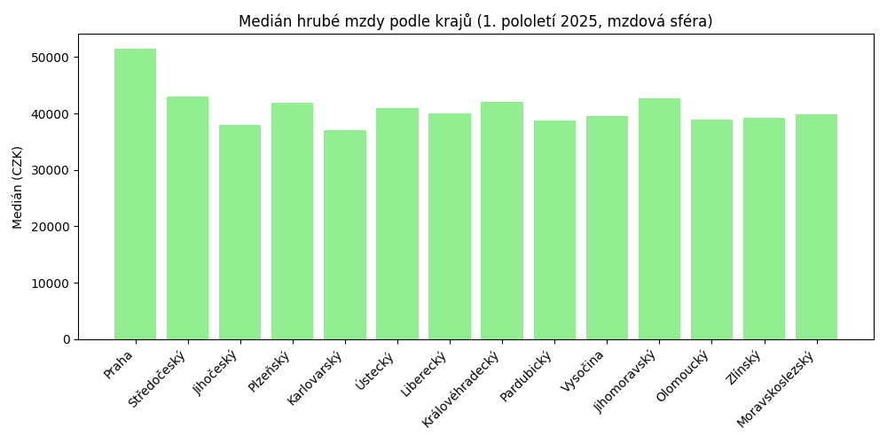

Медіанна зарплата за регіонами

## Зарплати за основними класами професій (CZ‑ISCO)

ISPV групує професії у дев’ять основних класів. У 1 півріччі 2025 р. найвищі заробітки мали **керівники** (řídící pracovníci) – медіана **94 908 Kč** (+8,6 % р/р) (ispv.cz). **Спеціалісти** (specialisté) заробляли медіанно **70 427 Kč** (+7,8 %) (ispv.cz). Найчисленніша група – **технічні й професійні працівники** – мала медіану **49 599 Kč** (640,4 тис. працівників) (ispv.cz). Наведена нижче таблиця підсумовує основні класи та їхні медіанні зарплати:

[output not shown]

*Для деяких груп Kurzy.cz не наводить точного приросту, але за даними ISPV приріст коливається у межах 5–8 %.

## Висновки

Використання офіційних даних ISPV дозволяє отримати точну та всеосяжну картину рівня заробітків у Чехії – від загальних тенденцій до конкретних професій і регіонів.

## Зарплати за секторами економіки та ключові спеціальності

ISPV публікує дані також за секціями економічної діяльності (класифікація **CZ‑NACE**). Таблиця нижче наводить медіанну та середню брутто‑зарплату у 1 півріччі 2025 р. за кожним сектором, а також приклади спеціальностей із цього сектора та їхні медіанні зарплати (дані ISPV – Zaměstnání). Прив’язка професій до секторів є орієнтовною: деякі професії можуть зустрічатися у кількох галузях.

[output not shown]

**Ключові спостереження:**

- **IT‑сектор** має найвищі середні доходи – 92 616 Kč на місяць, що на 79 % вище середнього рівня по країні. Високі зарплати забезпечують програмісти, системні аналітики й адміністратори баз даних (ispv.cz).
- **Фінансово‑страховий сектор** також має високі доходи: медіанна зарплата 67 265 Kč і середня 86 654 Kč (ispv.cz). Тут домінують менеджери й аналітики.
- **Енергетика** та **державне управління** демонструють вищі середні заробітки (понад 65 тис. Kč).
- **Готельно‑ресторанний бізнес** залишається найнижче оплачуваною галуззю – медіанна зарплата 26 038 Kč (ispv.cz).
- Сектора **освіти** та **охорони здоров’я** мають медіанні зарплати близько 42–47 тис. Kč, але всередині цих галузей є значний розрив між різними професіями (наприклад, лікарі заробляють майже 100 тис. Kč, тоді як молодший медичний персонал – близько 40 тис. Kč).